# TENSORFLOW INRODUCTION AND PRACTICE

- Tensorflow is an ML framework used to design,train and build deep learning models.
- It is an open source machine learning library.
- Tensor is a generalization of vectors and matrices to potentially higher dimensions
- Program takes a multidimensional array as an input and these arrays are called as tensors. We can construct a sort of flowchart of operations (a.k.a Graphs) that we want to perform on the tensor.
- Tensorflow sessions allow parts of Graphs or entire graph to be implemented

```python
#importing all necessary library modules

import tensorflow as tf
import numpy as np
from matplotlib import pyplot as plt
from tensorflow import keras  #keras is a neural network specific library
import tensorflow.compat.v1 as tf
tf.disable_v2_behavior
```

```
<function tensorflow.python.compat.v2_compat.disable_v2_behavior()>
```

```python
#defining variables using tf.Variable( value, type)

print("TensorFlow version:", tf.__version__)

string = tf.Variable("this is a sentence", tf.string)
floating = tf.Variable(3.23,tf.float64)
integer = tf.Variable(4,tf.int16)
```

[output not shown]

Rank/ degree means the dimensions of a tensor. The above tensors have a rank of 0, or is called as a scalar Shape attribute gives us the shape of the tensor, that is, the number of rows and columns

```python
rank1_tensor = tf.Variable(["tensor","flow"],tf.string)                            #rank1 tensor because 1 row or 1D
rank2_tensor = tf.Variable([["tensorflow","tensor"],["ai","ml"]],tf.string)        #rank2 tensor , a matrix

print(tf.rank(rank2_tensor))                 #tf.rank() gives us the rank of the tensor we input it into the attribute
print(tf.shape(rank1_tensor))
```

```
tf.Tensor(2, shape=(), dtype=int32)
tf.Tensor([2], shape=(1,), dtype=int32)
```

```python
ones_tensor = tf.ones([1,2,4])                   #creates a tensor of values 1 and of inputted shape
zeros_tensor = tf.zeros([5,5,5,5])
tf.reshape(ones_tensor,[2,4,1])                  # reshapes a given tensor to needed new dimension
```

```
<tf.Tensor 'Reshape:0' shape=(2, 4, 1) dtype=float32>
```

Types of Tensors: Constants , variable , placeholder , SparseTensor. Apart from variable, all the other types of tensors are immutable

To evaluate a tensor (to get its value) , we create a session One way to do it is:

```python
#using session
with tf.Session() as sess:
    print("using Session")
```

```
using Session
```

# NEURAL NETWORKS USING TENSORFLOW

```
(60000, 28, 28)
train_images has 60000 images each of which is 28x28 pixels
<class 'numpy.ndarray'>
```

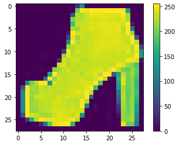

```python
fashion_mnist = keras.datasets.fashion_mnist    #load the dataset
( train_images , train_labels ) , (test_images , test_labels) = fashion_mnist.load_data()  #split the data set into training and test sets

class_names = ['T-shirt/top','Trouser','Pullover','Dress','Coat','Sandal','Shirt','Sneaker','Bag','Ankle boot']

print(train_images.shape)
print("train_images has 60000 images each of which is 28x28 pixels")
print(type(train_images))                       #type of dataset
plt.figure()
plt.imshow(train_images[44])                      #plotting of one of the elements of the dataset
plt.colorbar()
```

DATA PREPROCESSING

Data preprocessing is the reduction of the values in dataset to a value between -1 and 1. It is always a good idea to have our values in this range for simplifying computation. The weights are normally small values between -ve one and one, so when we multiply our data value with the weights, if there is a large difference in the size of these two values it leads to complexities and the weights have to work further to decrease the size of the inputted values. In simpler words, we aim to squish our values to the range -1 to 1.

How do we preprocess it ? divide by 255. Make sure to preprocess the training AND test set

```python
#preprocessing data
train_images = train_images / 255.0
test_images = test_images / 255.0
```

# Creating, training and testing our model

```python
#creating the model for the neural networks
# We are creating a sequential model here, which is the most basic model where information goes from left side to right side, with it passing through layers sequentially

model = keras.Sequential([

    #input layer
    keras.layers.Flatten(input_shape = (28,28)) , #flattens a matrix into a line of values with one column
    keras.layers.Dense(128, activation = 'relu'),  #hidden layer

   #Dense means every neuron in the input layer is connected to every neuron in this layer
   #128 here is the number of neurons
   #output layer must have as many neurons as our classes we are going to predict

    keras.layers.Dense(10,activation = 'softmax')   #output layer

])

# we mention the kind of hyperparameters needed
model.compile(optimizer = 'adam',
             loss = 'sparse_categorical_crossentropy',metrics = ['accuracy'])
#training the model

model.fit(train_images , train_labels , epochs = 5)

#The number of epochs is a hyperparameter that defines the number times that the learning algorithm will work through the entire training dataset
```

```
Train on 60000 samples
```

```
<keras.callbacks.History at 0x16bd2f1c0>
```

```python
#testing the model

test_loss , test_acc = model.evaluate(test_images , test_labels , verbose = 1)
print("The Test Accuracy and Test Loss is : " , test_acc, test_loss)
```

```
The Test Accuracy and Test Loss is :  0.7715 0.6566986353397369
```

*The keras. evaluate() function will give you the loss value for every batch. The keras. predict() function will give you the actual predictions for all samples in a batch, for all batches

```python
#making predictions
predictions = model.predict(test_images)
print(predictions)
```

```
[[1.9452480e-13 4.3209198e-20 1.4268874e-12 ... 1.4510365e-01
  3.6880048e-13 7.8885955e-01]
 [9.4032430e-06 1.5923211e-10 9.8928446e-01 ... 3.5970335e-36
  2.0883782e-07 2.3574749e-26]
 [1.6922602e-06 9.9699318e-01 3.4205987e-06 ... 5.2220152e-31
  1.1667027e-10 3.6525430e-38]
 ...
 [5.2762856e-09 0.0000000e+00 2.9934416e-08 ... 7.7427890e-12
  9.9999988e-01 3.5498201e-34]
 [1.6361342e-06 9.9599421e-01 2.5353900e-06 ... 3.7578353e-32
  7.8131369e-11 0.0000000e+00]
 [3.0228354e-03 2.0394837e-07 6.7474819e-03 ... 8.1393167e-02
  8.1082601e-03 7.8521736e-02]]
```